# MMSegmentation Tutorial

Welcome to MMSegmentation!

In this tutorial, we demo

- How to do inference with MMSeg trained weight
- How to train on your own dataset and visualize the results.

## Install MMSegmentation

This step may take several minutes.

```python
# Check nvcc version
!nvcc -V
# Check GCC version
!gcc --version
```

```python
# Install PyTorch
!conda install pytorch==1.12.0 torchvision==0.13.0 torchaudio==0.12.0 cudatoolkit=11.3 -c pytorch
# Install mim
!pip install -U openmim
# Install mmengine
!mim install mmengine
# Install MMCV
!mim install 'mmcv >= 2.0.0rc1'
```

```python
!rm -rf mmsegmentation
!git clone -b main https://github.com/open-mmlab/mmsegmentation.git
%cd mmsegmentation
!pip install -e .
```

```python
# Check Pytorch installation
import torch, torchvision
print(torch.__version__, torch.cuda.is_available())

# Check MMSegmentation installation
import mmseg
print(mmseg.__version__)
```

```
2.1.1+cu118 True
1.2.1
```

## Finetune a semantic segmentation model on a new dataset

To finetune on a customized dataset, the following steps are necessary.

1. Add a new dataset class.
2. Create a config file accordingly.
3. Perform training and evaluation.

### Add a new dataset

Datasets in MMSegmentation require image and semantic segmentation maps to be placed in folders with the same prefix. To support a new dataset, we may need to modify the original file structure.

In this tutorial, we give an example of converting the dataset. You may refer to [docs](https://github.com/open-mmlab/mmsegmentation/blob/master/docs/en/tutorials/customize_datasets.md#customize-datasets-by-reorganizing-data) for details about dataset reorganization.

We use [Stanford Background Dataset](http://dags.stanford.edu/projects/scenedataset.html) as an example. The dataset contains 715 images chosen from existing public datasets [LabelMe](http://labelme.csail.mit.edu), [MSRC](http://research.microsoft.com/en-us/projects/objectclassrecognition), [PASCAL VOC](http://pascallin.ecs.soton.ac.uk/challenges/VOC) and [Geometric Context](http://www.cs.illinois.edu/homes/dhoiem/). Images from these datasets are mainly outdoor scenes, each containing approximately 320-by-240 pixels. In this tutorial, we use the region annotations as labels. There are 8 classes in total, i.e. sky, tree, road, grass, water, building, mountain, and foreground object.

```python
# download and unzip
!wget http://dags.stanford.edu/data/iccv09Data.tar.gz -O stanford_background.tar.gz
!tar xf stanford_background.tar.gz
```

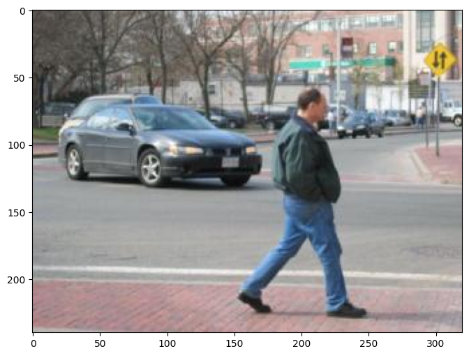

```python
import sys
sys.path.append('../')
# 这段代码将上一级目录（即当前工作目录的父目录）添加到 Python 的系统路径中。这样做之后，你就可以导入上一级目录中的模块或包了。

# Let's take a look at the dataset
import mmcv
import mmengine
import matplotlib.pyplot as plt


img = mmcv.imread('../iccv09Data/images/6000124.jpg')
plt.figure(figsize=(8, 6))
plt.imshow(mmcv.bgr2rgb(img))
plt.show()
```

We need to convert the annotation into semantic map format as an image.

```python
# define dataset root and directory for images and annotations
data_root = '../iccv09Data'
img_dir = 'images'
ann_dir = 'labels'
img_anno_dir = 'img_labels'  # 此处重新定义了img_labels的存放位置

# define class and palette for better visualization
classes = ('sky', 'tree', 'road', 'grass', 'water', 'bldg', 'mntn', 'fg obj')
palette = [[128, 128, 128], [129, 127, 38], [120, 69, 125], [53, 125, 34],
           [0, 11, 123], [118, 20, 12], [122, 81, 25], [241, 134, 51]]
```

```python
import os.path as osp
import numpy as np
from PIL import Image

# convert dataset annotation to semantic segmentation map
for file in mmengine.scandir(osp.join(data_root, ann_dir), suffix='.regions.txt'):
  seg_map = np.loadtxt(osp.join(data_root, ann_dir, file)).astype(np.uint8)
  seg_img = Image.fromarray(seg_map).convert('P')
  seg_img.putpalette(np.array(palette, dtype=np.uint8))
  seg_img.save(osp.join(data_root, ann_dir, file.replace('.regions.txt',
                                                         '.png')))
```

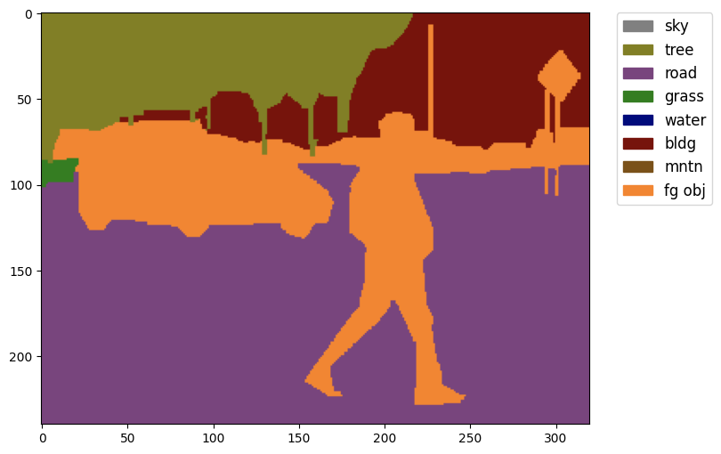

```python
import os.path as osp
import numpy as np
from PIL import Image

# Let's take a look at the segmentation map we got
import matplotlib.patches as mpatches
img = Image.open('../iccv09Data/img_labels/6000124.png')
plt.figure(figsize=(8, 6))
im = plt.imshow(np.array(img.convert('RGB')))

# create a patch (proxy artist) for every color
patches = [mpatches.Patch(color=np.array(palette[i])/255.,
                          label=classes[i]) for i in range(8)]
# put those patched as legend-handles into the legend
plt.legend(handles=patches, bbox_to_anchor=(1.05, 1), loc=2, borderaxespad=0.,
           fontsize='large')

plt.show()
```

```python
# split train/val set randomly
split_dir = 'splits'
mmengine.mkdir_or_exist(osp.join(data_root, split_dir))
filename_list = [osp.splitext(filename)[0] for filename in mmengine.scandir(
    osp.join(data_root, ann_dir), suffix='.png')]
with open(osp.join(data_root, split_dir, 'train.txt'), 'w') as f:
  # select first 4/5 as train set
  train_length = int(len(filename_list)*4/5)
  f.writelines(line + '\n' for line in filename_list[:train_length])
with open(osp.join(data_root, split_dir, 'val.txt'), 'w') as f:
  # select last 1/5 as train set
  f.writelines(line + '\n' for line in filename_list[train_length:])
```

```python
from mmseg.registry import DATASETS
from mmseg.datasets import BaseSegDataset


@DATASETS.register_module()
class StanfordBackgroundDataset(BaseSegDataset):
  METAINFO = dict(classes = classes, palette = palette)
  def __init__(self, **kwargs):
    super().__init__(img_suffix='.jpg', seg_map_suffix='.png', **kwargs)
```

### Create a config file

In the next step, we need to modify the config for the training. To accelerate the process, we finetune the model from trained weights.

```python
# Download config and checkpoint files
!mim download mmsegmentation --config pspnet_r50-d8_4xb2-40k_cityscapes-512x1024 --dest .
```

```python
from mmengine import Config
cfg = Config.fromfile('../configs/pspnet/pspnet_r50-d8_4xb2-40k_cityscapes-512x1024.py')
print(f'Config:\n{cfg.pretty_text}')
```

```
Config:
crop_size = (
    512,
    1024,
)
data_preprocessor = dict(
    bgr_to_rgb=True,
    mean=[
        123.675,
        116.28,
        103.53,
    ],
    pad_val=0,
    seg_pad_val=255,
    size=(
        512,
        1024,
    ),
    std=[
        58.395,
        57.12,
        57.375,
    ],
    type='SegDataPreProcessor')
data_root = 'data/cityscapes/'
dataset_type = 'CityscapesDataset'
default_hooks = dict(
    checkpoint=dict(by_epoch=False, interval=4000, type='CheckpointHook'),
    logger=dict(interval=50, log_metric_by_epoch=False, type='LoggerHook'),
    param_scheduler=dict(type='ParamSchedulerHook'),
    sampler_seed=dict(type='DistSamplerSeedHook'),
    timer=dict(type='IterTimerHook'),
    visualization=dict(type='SegVisualizationHook'))
default_scope = 'mmseg'
env_cfg = dict(
    cudnn_benchmark=True,
    dist_cfg=dict(backend='nccl'),
    mp_cfg=dict(mp_start_method='fork', opencv_num_threads=0))
img_ratios = [
    0.5,
```

[output cut: 238 more lines]

```
    persistent_workers=True,
    sampler=dict(shuffle=False, type='DefaultSampler'))
val_evaluator = dict(
    iou_metrics=[
        'mIoU',
    ], type='IoUMetric')
vis_backends = [
    dict(type='LocalVisBackend'),
]
visualizer = dict(
    name='visualizer',
    type='SegLocalVisualizer',
    vis_backends=[
        dict(type='LocalVisBackend'),
    ])
```

Since the given config is used to train PSPNet on the cityscapes dataset, we need to modify it accordingly for our new dataset.  
翻译： 由于给定的配置是用来在cityscapes数据集上训练PSPNet的，我们需要相应地修改它以适应我们的新数据集。

```python
# Since we use only one GPU, BN is used instead of SyncBN
cfg.norm_cfg = dict(type='BN', requires_grad=True)
cfg.crop_size = (256, 256)
cfg.model.data_preprocessor.size = cfg.crop_size
cfg.model.backbone.norm_cfg = cfg.norm_cfg
cfg.model.decode_head.norm_cfg = cfg.norm_cfg
cfg.model.auxiliary_head.norm_cfg = cfg.norm_cfg
# modify num classes of the model in decode/auxiliary head
cfg.model.decode_head.num_classes = 8
cfg.model.auxiliary_head.num_classes = 8

# Modify dataset type and path
cfg.dataset_type = 'StanfordBackgroundDataset'
cfg.data_root = data_root

cfg.train_dataloader.batch_size = 8

cfg.train_pipeline = [
    dict(type='LoadImageFromFile'),
    dict(type='LoadAnnotations'),
    dict(type='RandomResize', scale=(320, 240), ratio_range=(0.5, 2.0), keep_ratio=True),
    dict(type='RandomCrop', crop_size=cfg.crop_size, cat_max_ratio=0.75),
    dict(type='RandomFlip', prob=0.5),
    dict(type='PackSegInputs')
]

cfg.test_pipeline = [
    dict(type='LoadImageFromFile'),
    dict(type='Resize', scale=(320, 240), keep_ratio=True),
    # add loading annotation after ``Resize`` because ground truth
    # does not need to do resize data transform
    dict(type='LoadAnnotations'),
    dict(type='PackSegInputs')
]


cfg.train_dataloader.dataset.type = cfg.dataset_type
cfg.train_dataloader.dataset.data_root = cfg.data_root
cfg.train_dataloader.dataset.data_prefix = dict(img_path=img_dir, seg_map_path=img_anno_dir)
cfg.train_dataloader.dataset.pipeline = cfg.train_pipeline
cfg.train_dataloader.dataset.ann_file = 'splits/train.txt'

cfg.val_dataloader.dataset.type = cfg.dataset_type
cfg.val_dataloader.dataset.data_root = cfg.data_root
cfg.val_dataloader.dataset.data_prefix = dict(img_path=img_dir, seg_map_path=img_anno_dir)
cfg.val_dataloader.dataset.pipeline = cfg.test_pipeline
cfg.val_dataloader.dataset.ann_file = 'splits/val.txt'

cfg.test_dataloader = cfg.val_dataloader  # 此处test同val


# Load the pretrained weights
cfg.load_from = '../test/get_start/pspnet_r50-d8_512x1024_40k_cityscapes_20200605_003338-2966598c.pth'

# Set up working dir to save files and logs.
cfg.work_dir = './work_dirs/tutorial'

cfg.train_cfg.max_iters = 200
cfg.train_cfg.val_interval = 200  # 验证的间隔，隔几次进行一次验证
cfg.default_hooks.logger.interval = 10  # 日志的间隔，隔几次进行一次日志记录
cfg.default_hooks.checkpoint.interval = 200  # 模型的保存间隔，隔几次进行一次模型保存

# Set seed to facilitate reproducing the result
cfg['randomness'] = dict(seed=0)

# Let's have a look at the final config used for training
print(f'Config:\n{cfg.pretty_text}')
```

```
Config:
crop_size = (
    256,
    256,
)
data_preprocessor = dict(
    bgr_to_rgb=True,
    mean=[
        123.675,
        116.28,
        103.53,
    ],
    pad_val=0,
    seg_pad_val=255,
    size=(
        512,
        1024,
    ),
    std=[
        58.395,
        57.12,
        57.375,
    ],
    type='SegDataPreProcessor')
data_root = '../iccv09Data'
dataset_type = 'StanfordBackgroundDataset'
default_hooks = dict(
    checkpoint=dict(by_epoch=False, interval=200, type='CheckpointHook'),
    logger=dict(interval=10, log_metric_by_epoch=False, type='LoggerHook'),
    param_scheduler=dict(type='ParamSchedulerHook'),
    sampler_seed=dict(type='DistSamplerSeedHook'),
    timer=dict(type='IterTimerHook'),
    visualization=dict(type='SegVisualizationHook'))
default_scope = 'mmseg'
env_cfg = dict(
    cudnn_benchmark=True,
    dist_cfg=dict(backend='nccl'),
    mp_cfg=dict(mp_start_method='fork', opencv_num_threads=0))
img_ratios = [
    0.5,
```

[output cut: 238 more lines]

```
    sampler=dict(shuffle=False, type='DefaultSampler'))
val_evaluator = dict(
    iou_metrics=[
        'mIoU',
    ], type='IoUMetric')
vis_backends = [
    dict(type='LocalVisBackend'),
]
visualizer = dict(
    name='visualizer',
    type='SegLocalVisualizer',
    vis_backends=[
        dict(type='LocalVisBackend'),
    ])
work_dir = './work_dirs/tutorial'
```

### Train and Evaluation

```python
# start training
runner.train()
```

```
11/26 08:29:37 - mmengine - WARNING - The prefix is not set in metric class IoUMetric.
11/26 08:29:38 - mmengine - INFO - load model from: open-mmlab://resnet50_v1c
11/26 08:29:38 - mmengine - INFO - Loads checkpoint by openmmlab backend from path: open-mmlab://resnet50_v1c
```

```
Downloading: "https://download.openmmlab.com/pretrain/third_party/resnet50_v1c-2cccc1ad.pth" to /root/.cache/torch/hub/checkpoints/resnet50_v1c-2cccc1ad.pth
```

```
11/26 08:30:06 - mmengine - WARNING - The model and loaded state dict do not match exactly

unexpected key in source state_dict: fc.weight, fc.bias

Loads checkpoint by local backend from path: ../test/get_start/pspnet_r50-d8_512x1024_40k_cityscapes_20200605_003338-2966598c.pth
The model and loaded state dict do not match exactly

size mismatch for decode_head.conv_seg.weight: copying a param with shape torch.Size([19, 512, 1, 1]) from checkpoint, the shape in current model is torch.Size([8, 512, 1, 1]).
size mismatch for decode_head.conv_seg.bias: copying a param with shape torch.Size([19]) from checkpoint, the shape in current model is torch.Size([8]).
size mismatch for auxiliary_head.conv_seg.weight: copying a param with shape torch.Size([19, 256, 1, 1]) from checkpoint, the shape in current model is torch.Size([8, 256, 1, 1]).
size mismatch for auxiliary_head.conv_seg.bias: copying a param with shape torch.Size([19]) from checkpoint, the shape in current model is torch.Size([8]).
11/26 08:30:07 - mmengine - INFO - Load checkpoint from ../test/get_start/pspnet_r50-d8_512x1024_40k_cityscapes_20200605_003338-2966598c.pth
11/26 08:30:07 - mmengine - WARNING - "FileClient" will be deprecated in future. Please use io functions in https://mmengine.readthedocs.io/en/latest/api/fileio.html#file-io
11/26 08:30:07 - mmengine - WARNING - "HardDiskBackend" is the alias of "LocalBackend" and the former will be deprecated in future.
11/26 08:30:07 - mmengine - INFO - Checkpoints will be saved to /home/sylu/workspace/mjg/mmsegmentation/demo/work_dirs/tutorial.
11/26 08:30:25 - mmengine - INFO - Iter(train) [ 10/200]  lr: 9.9980e-03  eta: 0:05:42  time: 1.8006  data_time: 0.0171  memory: 11667  loss: 2.2998  decode.loss_ce: 1.5896  decode.acc_seg: 76.7940  aux.loss_ce: 0.7102  aux.acc_seg: 73.4310
11/26 08:30:28 - mmengine - INFO - Iter(train) [ 20/200]  lr: 9.9958e-03  eta: 0:03:13  time: 0.3532  data_time: 0.0134  memory: 3530  loss: 1.4174  decode.loss_ce: 0.8829  decode.acc_seg: 84.3241  aux.loss_ce: 0.5344  aux.acc_seg: 84.8316
11/26 08:30:33 - mmengine - INFO - Iter(train) [ 30/200]  lr: 9.9935e-03  eta: 0:02:27  time: 0.4434  data_time: 0.0135  memory: 3530  loss: 1.0933  decode.loss_ce: 0.7062  decode.acc_seg: 75.1990  aux.loss_ce: 0.3871  aux.acc_seg: 69.3539
11/26 08:30:37 - mmengine - INFO - Iter(train) [ 40/200]  lr: 9.9913e-03  eta: 0:02:02  time: 0.4545  data_time: 0.0136  memory: 3530  loss: 1.0229  decode.loss_ce: 0.6893  decode.acc_seg: 78.7009  aux.loss_ce: 0.3335  aux.acc_seg: 82.3593
11/26 08:30:42 - mmengine - INFO - Iter(train) [ 50/200]  lr: 9.9891e-03  eta: 0:01:44  time: 0.4390  data_time: 0.0126  memory: 3530  loss: 0.9650  decode.loss_ce: 0.6523  decode.acc_seg: 74.8154  aux.loss_ce: 0.3127  aux.acc_seg: 69.4421
11/26 08:30:46 - mmengine - INFO - Iter(train) [ 60/200]  lr: 9.9869e-03  eta: 0:01:31  time: 0.4513  data_time: 0.0133  memory: 3530  loss: 0.8838  decode.loss_ce: 0.6063  decode.acc_seg: 76.8747  aux.loss_ce: 0.2775  aux.acc_seg: 74.2659
11/26 08:30:51 - mmengine - INFO - Iter(train) [ 70/200]  lr: 9.9846e-03  eta: 0:01:21  time: 0.4591  data_time: 0.0135  memory: 3530  loss: 0.9396  decode.loss_ce: 0.6443  decode.acc_seg: 68.7333  aux.loss_ce: 0.2953  aux.acc_seg: 69.5985
11/26 08:30:52 - mmengine - INFO - Exp name: pspnet_r50-d8_4xb2-40k_cityscapes-512x1024_20231126_082924
11/26 08:30:55 - mmengine - INFO - Iter(train) [ 80/200]  lr: 9.9824e-03  eta: 0:01:12  time: 0.4219  data_time: 0.0136  memory: 3530  loss: 0.8661  decode.loss_ce: 0.5972  decode.acc_seg: 80.0673  aux.loss_ce: 0.2690  aux.acc_seg: 81.5561
11/26 08:30:59 - mmengine - INFO - Iter(train) [ 90/200]  lr: 9.9802e-03  eta: 0:01:04  time: 0.4401  data_time: 0.0129  memory: 3530  loss: 0.8365  decode.loss_ce: 0.5696  decode.acc_seg: 89.5195  aux.loss_ce: 0.2669  aux.acc_seg: 86.4726
11/26 08:31:04 - mmengine - INFO - Iter(train) [100/200]  lr: 9.9779e-03  eta: 0:00:57  time: 0.4506  data_time: 0.0136  memory: 3530  loss: 0.7404  decode.loss_ce: 0.5049  decode.acc_seg: 76.7646  aux.loss_ce: 0.2355  aux.acc_seg: 76.5601
```

[output cut: 40 more lines]

[output not shown]

[output cut: 191 more lines]

[output not shown]

Inference with trained model

```
Loads checkpoint by local backend from path: ./work_dirs/tutorial/iter_200.pth
```

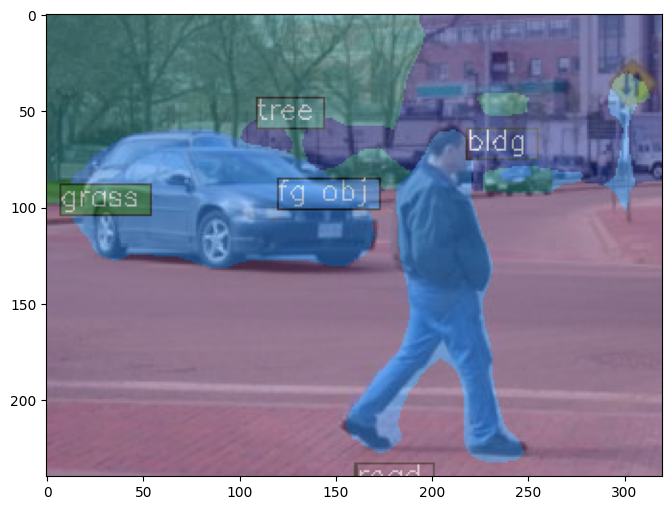

```python
from mmseg.apis import init_model, inference_model, show_result_pyplot

# Init the model from the config and the checkpoint
checkpoint_path = './work_dirs/tutorial/iter_200.pth'
model = init_model(cfg, checkpoint_path, 'cuda:0')

img = mmcv.imread('../iccv09Data/images/6000124.jpg')
result = inference_model(model, img)
plt.figure(figsize=(8, 6))
vis_result = show_result_pyplot(model, img, result)
plt.imshow(mmcv.bgr2rgb(vis_result))
```